# TP2 - Logiciel statistique R

## I. Importation et mise en forme

Pour importer le jeu de données, nous faisons appel à la focntion `read_xlsx()` de la librairie **readxl** qui facilite l’extraction de données d’Excel vers R. Après avoir importé la base de données sur laquelle nous allons travailler, nous pouvons procéder à l’affichage de quelques les premières lignes.

```r
library(readxl)

base_tp2 <- read_xlsx("..//Donnees//Base TP2.xlsx")
head(base_tp2)
```

```
## # A tibble: 6 × 30
##   region departement  sexe   age sit_mat si_chef_men ethnie occupation formation
##    <dbl>       <dbl> <dbl> <dbl>   <dbl>       <dbl>  <dbl>      <dbl>     <dbl>
## 1      5          53     2    35       1           1     10         22         4
## 2      5          53     1    50       1           2      1          1         1
## 3      2          22     2    35       1           1      1          1         3
## 4      1          12     1    25       1           3      3         22         5
## 5      5          52     2    60       1           1     77          1         3
## 6      3          31     1    36       1           1      3          1        99
## # ℹ 21 more variables: niveau_alphabs <dbl>, types_varietes <chr>,
## #   types_varietes_1 <dbl>, types_varietes_2 <dbl>, criteres_var <chr>,
## #   criteres_var_1 <dbl>, criteres_var_2 <dbl>, criteres_var_3 <dbl>,
## #   criteres_var_4 <dbl>, criteres_var_5 <dbl>, criteres_var_6 <dbl>,
## #   criteres_var_7 <dbl>, criteres_var_8 <dbl>, criteres_var_9 <dbl>,
## #   criteres_var_10 <dbl>, criteres_var_11 <dbl>, criteres_var_12 <dbl>,
## #   criteres_var_13 <dbl>, criteres_var_14 <dbl>, criteres_var_15 <dbl>, …
```

Pour obtenir des informations détaillées sur une base de données, nous pouvons tiliser la fonction `str()`.

```r
str(base_tp2)
```

```
## tibble [53 × 30] (S3: tbl_df/tbl/data.frame)
##  $ region          : num [1:53] 5 5 2 1 5 3 3 2 2 4 ...
##  $ departement     : num [1:53] 53 53 22 12 52 31 32 22 22 41 ...
##  $ sexe            : num [1:53] 2 1 2 1 2 1 2 1 1 1 ...
##  $ age             : num [1:53] 35 50 35 25 60 36 25 56 55 80 ...
##  $ sit_mat         : num [1:53] 1 1 1 1 1 1 1 1 1 1 ...
##  $ si_chef_men     : num [1:53] 1 2 1 3 1 1 3 2 2 2 ...
##  $ ethnie          : num [1:53] 10 1 1 3 77 3 3 1 1 2 ...
##  $ occupation      : num [1:53] 22 1 1 22 1 1 15 1 1 1 ...
##  $ formation       : num [1:53] 4 1 3 5 3 99 1 1 1 1 ...
##  $ niveau_alphabs  : num [1:53] NA 0 NA NA NA NA 1 0 0 0 ...
##  $ types_varietes  : chr [1:53] "2" "1" "1" "1" ...
##  $ types_varietes_1: num [1:53] 0 1 1 1 1 1 1 1 0 1 ...
##  $ types_varietes_2: num [1:53] 1 0 0 0 0 1 0 0 1 0 ...
##  $ criteres_var    : chr [1:53] "1 12 13" "1 4 6 7 11 13" "1 5 6" "1 4 6 7 14 15" ...
```

[output cut: 16 more lines]

La base de données est composée de 53 observations et de 30 variables comme nous montre la ligne ci-après grâce à la fonction `dim()`

```r
dim(base_tp2)
```

```
## [1] 53 30
```

## II. Recodage et labélisation

### II.1. Recodage

```r
base_tp2$sexe = dplyr::recode_factor(base_tp2$sexe,
                     '1'="Homme",
                     '2'="Femme")
```

```r
class(base_tp2$sexe)
```

```
## [1] "factor"
```

```r
typeof(base_tp2$sexe)
```

```
## [1] "integer"
```

```r
base_tp2$sit_mat = dplyr::recode_factor(base_tp2$sit_mat,
                     '1'="Marie(e)",
                     '3'="Veuf(ve)",
                     '4'="Divorce(e)",
                     '5'="Separe(e)",
                     '6'="Celibataire")
```

```r
base_tp2$si_chef_men = dplyr::recode_factor(base_tp2$si_chef_men,
                     '1'="femme du chef de menage",
                     '3'="chef de menage",
                     '4'="fils-fille du chef de menage",
                     '99'="Autres")
```

```r
base_tp2$ethnie = dplyr::recode_factor(base_tp2$ethnie,
                     '1'="Wolof",
                     '2'="Pulaar/Toucouleur",
                     '3'="Serere",
                     '4'="Mandika/Bambara",
                     '5'="Soninke",
                     '6'="Diola",
                     '7'="Manjack",
                     '8'="Bainouk",
                     '9'="Maures",
                     '10'="Balante",
                     '77'="Autre")
```

```r
base_tp2$occupation =
  dplyr::recode_factor(base_tp2$occupation,
                     '1'="Agriculture, Elevage, Sylvicuture, Peche",
                     '2'="Activites extractives",
                     '3'="Activites de fabrications (Artisanat)",
                     '4'="Activite de transformation",
                     '5'="Production et distribution d'electricite\
                     et de gaz",
                     '6'="Production et distribution d'eau, assainissement,\
                     traitement des dechets et depollution")
```

```r
base_tp2$formation = dplyr::recode_factor(base_tp2$formation,
                     '1'="Non scolarise",
                     '2'="Elementaire",
                     '3'="Moyen",
                     '4'="Secondaire",
                     '5'="Licence",
                     '6'="Master",
                     '7'="Doctorat",
                     '99'="Ne sait pas")
```

```r
base_tp2$niveau_alphabs = dplyr::recode_factor(base_tp2$niveau_alphabs,
                     '0'="Sans niveau",
                     '1'="Sait lire dans une langue",
                     '2'="Sait lire et ecrire dans une langue")
```

```r
YesNo = function(data, var){
  data[[var]] = dplyr::recode_factor(data[[var]],
                     '0'="Non",
                     '1'="Oui",
                     .default = "Missing")
}
```

```r
## Types de variétés
YesNo(base_tp2, "types_varietes_1")

YesNo(base_tp2, "types_varietes_2")


## Critères de choix de variétés
vars2 = paste0("criteres_var_",1:16)

for (var in vars2){
  base_tp2[[var]] = YesNo(base_tp2, var)
}
```

### II.2. Labélisation

Labéliser une variable consiste à lui attribuer une description explicite afin de mieux comprendre sa signification. Pour ce faire, utilisons la fonction `apply_labels()` de la librairie **expss**.

```r
library(expss)

base_tp2 <- base_tp2|> expss::apply_labels(
  region = "Region", departement = "Departement",
  sexe = "Sexe", age = "Age",
  sit_mat = "Situation matrimoniale",
  si_chef_men = "Statut dans le menage",
  ethnie = "Ethnie", occupation = "Occupation",
  formation = "Formation",
  niveau_alphabs = "Niveau d'alphabetisation",
  types_varietes = "Quelles sont les varietes que vous utilisez\
  pour la production de sesame ?",
  types_varietes_1 = "Traditionnelles",
  types_varietes_2 = "Améliorées",
  criteres_var = "Quels sont les criteres de choix des varietes de sesame ?",
  criteres_var_1 = "Rendements eleves",
  criteres_var_2 = "Taille des graines",
  criteres_var_3 = "Resistantes aux maladies/ravageurs",
  criteres_var_4 = "Tolerantes aux secheresses",
  criteres_var_5 = "Tolerantes aux inondations",
  criteres_var_6 = "Faible charge de travail",
  criteres_var_7 = "Faibles quantites d'intrants",
  criteres_var_8 = "Facile à transformer",
  criteres_var_9 = "Haute teneur en huile",
  criteres_var_10 = "Haut rendement apres transformation",
  criteres_var_11 = "Demande sur le marché",
  criteres_var_12 = "Bon gout",
  criteres_var_13 = "Belle couleur",
  criteres_var_14 = "Haut rendement en fourrages",
  criteres_var_15 = "Qualité du fourrage",
  criteres_var_16 = "Autres a specifier"
)
```

## III. Analyse descriptive

Dans cette partie, Pour automatiser les affichages de tableaux et de graphes dans le cadre de l’analyse descriptive, nous allons développer deux fonctions : univarie() et bivarie().

### III.1. La fonction univarie

```r
univarie <- function(data, var, tab = TRUE,
                     plot=FALSE,type="",props = TRUE)
  {

  ## Librairies
  library(gtsummary)
  library(ggplot2)
  library(gt)
  library(dplyr)
  attach(data)

  ## Variable qualitative
    if (is.character(var)==TRUE | is.factor(var)==TRUE){

      # Tableau des effectifs
      df = data.frame(table(var))
      names(df) = c("var","eff")

      # Tableau des fréquences
      dfprop = data.frame(round(proportions(table(var))*100,2))
      names(dfprop) = c("var","freq")

      # Tableau de resultat
      table = data.frame(var) |> tbl_summary()

      # Diagramme en secteurs
      plot1 = ggplot(dfprop,
                aes(x = "", y = freq, fill =var)) +
              geom_bar(stat = "identity", width=1) +
              coord_polar(theta = "y", start = 0) +
              geom_text(aes(label = paste(freq,"%")),color="white",
                        position = position_stack(vjust=0.5))+
              labs(fill = attr(var,"label")) +
              theme_void()

      # Diagramme en barres avec les effectifs
      plot2_eff = ggplot(df,
                aes(x = var, y = eff, fill = var)) +
              geom_bar(stat = "identity", width=1) +
              labs(fill = attr(var,"label")) +
              theme(legend.position = "none")

      # Diagramme en barres avec les fréquences
      plot2_freq = ggplot(dfprop,
                aes(x = var, y = freq, fill = var)) +
              geom_bar(stat = "identity", width=1) +
              labs(fill = attr(var,"label")) +
              theme(legend.position = "none")
    }

  ## Variable discrète
  else if (is.numeric(var)==TRUE){

      # Tri à plat
      dftri = data.frame(var)
      names(dftri) = "var"

      # Tableau des statistiques descriptives (Tendance centrale)
      min = min(var, na.rm = TRUE)
      q1 = quantile(var, na.rm = TRUE, 0.25)
      median = median(var, na.rm = TRUE)
      mean = mean(var, na.rm = TRUE)
      sd = sd(var, na.rm = TRUE)
      variance = sd^2
      q3 = quantile(var, na.rm = TRUE, 0.75)
      max = max(var, na.rm = TRUE)
      stats =  c(min,q1,median,mean,sd,variance,q3,max)
      statsLab = c("Minimum", "1er quartile","Médiane",
                   "Moyenne", "Ecart-type", "Variance",
                   "3e quartile", "Maximum")
      table = data.frame(
        Statistiques = statsLab,
        Valeurs = stats
      )
  }

  ## Sorties : graphiques ou tableaux
  if (tab == TRUE){result = table}

  else if(plot == TRUE){
    tab = FALSE
    if (type == "pie"){result = plot1}
    else{
      if(props == FALSE){result = plot2_eff}
      else{result = plot2_freq}
      }
  }

  else if (plot == TRUE){
    tab = FALSE
    result = plot2
  }
  else {result = print("Spécifier les arguments")}

  return(result)
}
```

```r
univarie(base_tp2, age)
```

```
##   Statistiques   Valeurs
## 1      Minimum  24.00000
## 2 1er quartile  39.00000
## 3      Médiane  49.00000
## 4      Moyenne  48.60377
## 5   Ecart-type  12.91293
## 6     Variance 166.74383
## 7  3e quartile  58.00000
## 8      Maximum  80.00000
```

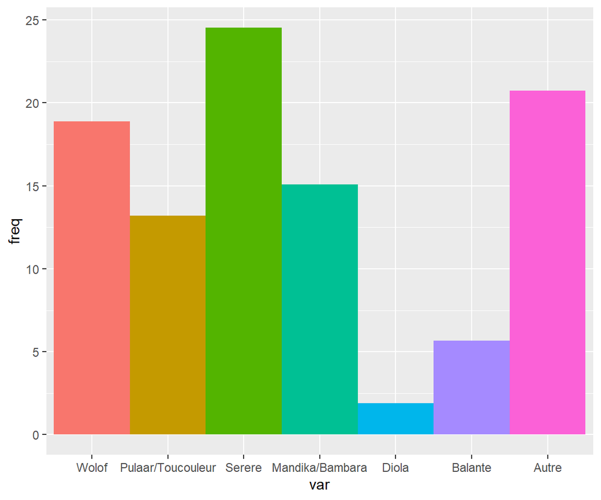

```r
univarie(base_tp2, ethnie, plot = TRUE, tab = FALSE, props = TRUE)
```

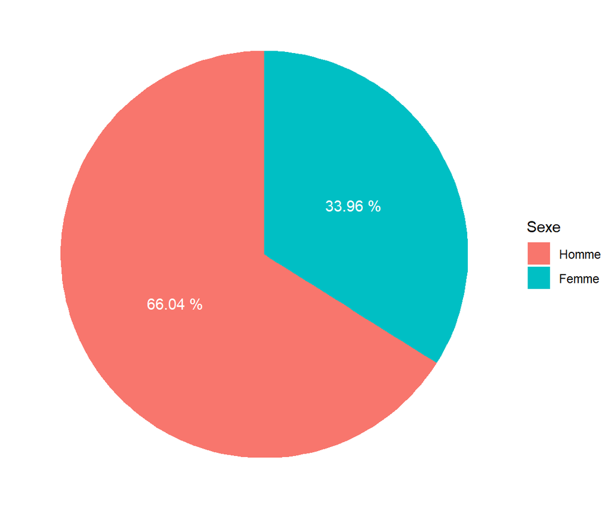

```r
univarie(base_tp2, sexe, plot = TRUE, tab = FALSE, props = TRUE, type="pie")
```

```r
univarie(base_tp2, formation, tab = TRUE)
```

| **Characteristic** | **N = 53**<sup>1</sup> |
| --- | --- |
| Formation |  |
| Non scolarise | 30 (57%) |
| Elementaire | 10 (19%) |
| Moyen | 7 (13%) |
| Secondaire | 3 (5.7%) |
| Licence | 2 (3.8%) |
| Ne sait pas | 1 (1.9%) |

<sup>1</sup> n (%)

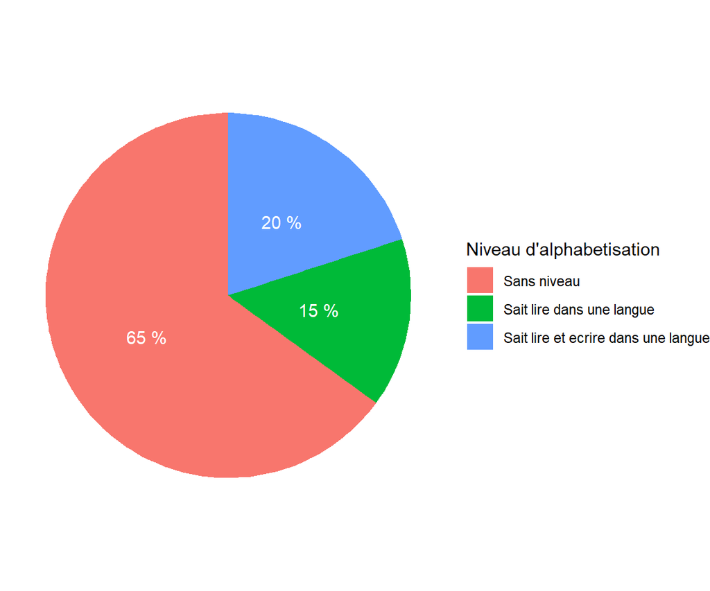

```r
univarie(base_tp2, niveau_alphabs, plot = TRUE,
         tab = FALSE, props = TRUE, type="pie")
```

### III.2. La fonction bivarie

Elle prend en argument le jeu de données (**data**) et les deux variables ( var1 , var2 ). Il est à noter que cette fonction ne prend en charge que des variables qualitatives. Avec son option par défaut **all=TRUE** , elle affiche le tableau croisé ainsi que le diagramme des deux variables. Tout comme la fonction **univarie()**, elle peut afficher uniquement le graphique ou le tableau avec les mêmes options. Ces fonctions nous permettront de généraliser les statistiques descriptives en fonction du type de variable.

```r
bivarie <- function(df, var1, var2, all=TRUE){
  library(gtsummary)
  library(ggplot2)
  attach(df)

  ## Variable qualitative
  if (is.character(var1)==TRUE){
    df_plot = data.frame(table(var1, var2))
    names(df_plot) = c("Var1","Var2","Freq")

    plot = ggplot(df_plot,
               aes(x = Var1, y = Freq, fill = Var2)) +
            geom_bar(stat = "identity", position = "fill")

    table = tbl_cross(df, df$var1, df$var2)
  }

  ## Sorties : graphiques ou tableaux
  if (all==TRUE){res = list(table,plot)}
  else if(all=="table"){res = table}
  else if(all=="plot"){res = plot}
  else {res = print("Choisir l'option table ou plot")}

  return(res)
}
```

```r
bivarie(base_tp2, sexe, ethnie)[[1]]
```

[output not shown]

[output cut: 58 more lines]

[output not shown]